# Last fixation explanation

## Last fixation effect

People remember the thing they look at last 94% of the time. In value-based decision making, it has been suggested that this last-fixation effect could explain away what looks to be evidence for adaptive attention allocation. This claim did not hold up there, but it could nevertheless be affecting our results.

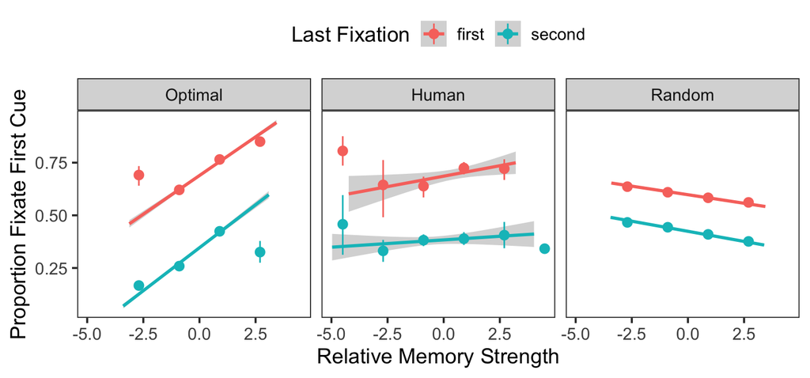

```r
df %>%
    filter(n_pres >= 2) %>%
    ggplot(aes(rel_strength, prop_first, color=last_pres)) +
    geom_smooth(method="lm") +
    stat_summary_bin(fun.data=mean_cl_boot, bins=5) +
    facet_wrap(~name) +
    theme(legend.position="top") +
    labs(x="Relative Memory Strength", y="Proportion Fixate First Cue", color="Last Fixation")
```

```r
X = df %>% filter(n_pres > 1 & name == "Human")
lmer(prop_first ~ rel_strength * last_pres + (rel_strength * last_pres | wid), data=X) %>% summ
```

| Fixed Effects | Fixed Effects Est. | Fixed Effects S.E. | Fixed Effects t val. | Fixed Effects d.f. | Fixed Effects p |
| --- | --- | --- | --- | --- | --- |
| (Intercept) | 0.670 | 0.019 | 34.506 | 39.089 | 0.000 |
| rel_strength | 0.028 | 0.011 | 2.589 | 28.621 | 0.015 |
| last_pressecond | -0.285 | 0.026 | -10.934 | 44.352 | 0.000 |
| rel_strength:last_pressecond | -0.025 | 0.012 | -2.103 | 47.334 | 0.041 |

p values calculated using Satterthwaite d.f.

The effect of relative memory strength on fixation proportion is a lot weaker when we control for the effect of the last fixation, but it remains significant.

## Explanation

What’s going on here? Basically it is due to the last fixation being correlated with both fixation proportion and relative strength. The first item is fixated longer on trials where the first cue is seen last (because it has one more fixation than the other cue).

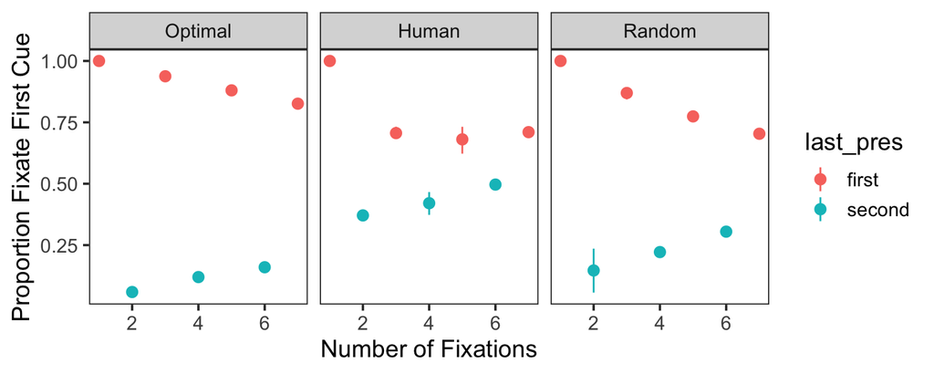

```r
df %>%
    filter(n_pres < 8) %>%
    ggplot(aes(n_pres, prop_first, color=last_pres)) +
    facet_wrap(~name) +
    labs(x='Number of Fixations', y='Proportion Fixate First Cue') +
    stat_summary(fun.data=mean_cl_boot)
```

Furthermore, relative strength is higher for trials where the last fixation is on the first item. This is (presumably) because people tend to remember the cue they look at last and they are also more likely to remember the stronger pair.

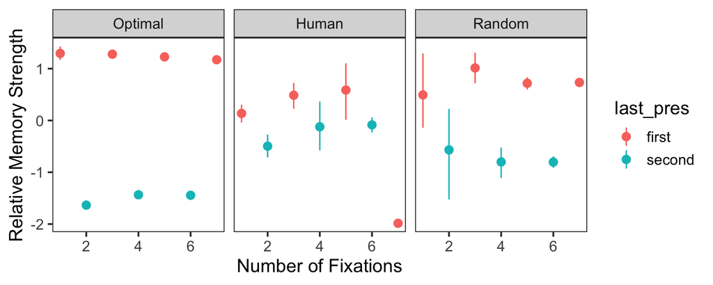

```r
df %>%
    filter(n_pres < 8) %>%
    ggplot(aes(n_pres, rel_strength, color=last_pres)) +
    facet_wrap(~name) +
    labs(x="Number of Fixations", y="Relative Memory Strength") +
    stat_summary(fun.data=mean_cl_boot)
```

Putting the last two effects together, we get a correlation between strength and fixation proportion based only on the target of the last fixation.

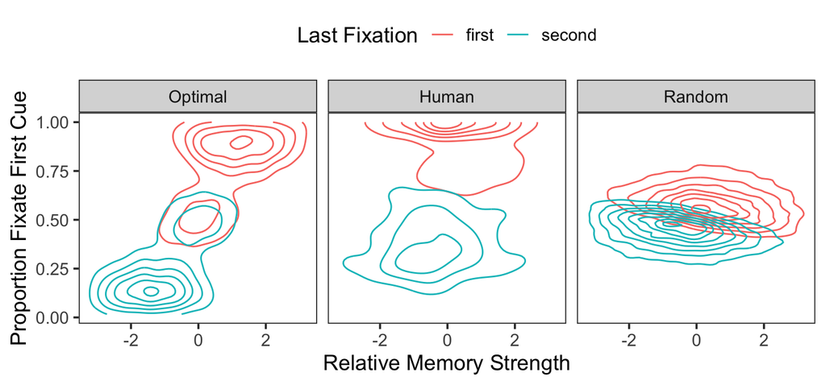

```r
df %>%
    ggplot(aes(rel_strength, prop_first, color=last_pres)) +
    # geom_point() +
    # geom_errorbar(aes(ymin=prop_first_mean - prop_first_sd, ymax=prop_first_mean + prop_first_sd)) +
    # geom_errorbarh(aes(xmin=rel_strength_mean - rel_strength_sd, xmax=rel_strength_mean + rel_strength_sd)) +
    geom_density_2d() +
    facet_wrap(~name) +
    theme(legend.position="top") +
    labs(x="Relative Memory Strength", y="Proportion Fixate First Cue", color="Last Fixation")
```

It might be easier to see if we group the data by number of fixations:

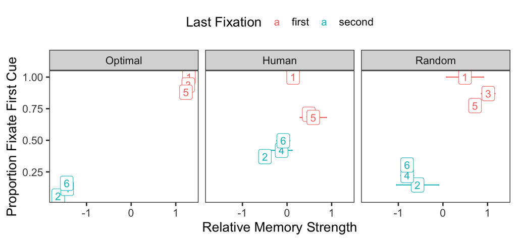

```r
df %>%
    filter(between(n_pres, 1, 6)) %>%
    group_by(name, last_pres, n_pres) %>%
    summarise(across(c(rel_strength, prop_first), list(mean=mean, sd=~ sd(.x) / sqrt(length(.x))))) %>%
    ggplot(aes(rel_strength_mean, prop_first_mean, color=last_pres, label=n_pres)) +
    geom_errorbar(aes(ymin=prop_first_mean - prop_first_sd, ymax=prop_first_mean + prop_first_sd)) +
    geom_errorbarh(aes(xmin=rel_strength_mean - rel_strength_sd, xmax=rel_strength_mean + rel_strength_sd)) +
    facet_wrap(~name) +
    theme(legend.position="top") +
    labs(x="Relative Memory Strength", y="Proportion Fixate First Cue", color="Last Fixation") +
    geom_label()
```